# Valuation Office Open Data

Mick O Donnell

5/9/2021

# Introduction

Downloading and gathering…

*Note - you will need to change the eval tag to TRUE for the next chunk to run - I deactivated it as it takes a couple of minutes, plus it’s an unnecessary call on the API as we have the data saved locally*

```r
# download the data - it is only possible to pull down one local authority's data at a time, so a vector of local authority names is necessary.. I've had to correct dlrcc's name manually

la_names <- read_csv("data/Administrative_Areas_-_OSi_National_Statutory_Boundaries_-_Generalised_20m.csv") %>%   select(ENGLISH) %>%
  mutate(ENGLISH = ifelse(ENGLISH == "DUN LAOGHAIRE-RATHDOWN COUNTY COUNCIL",
                          "DUN LAOGHAIRE RATHDOWN CO CO", ENGLISH)) %>%
  mutate(la = str_replace_all(ENGLISH, " ", "%20"))

valoff_query_api_str <- "https://api.valoff.ie/api/Property/GetProperties?Fields=*&LocalAuthority=la_string&CategorySelected=OFFICE%2CFUEL%2FDEPOT%2CLEISURE%2CINDUSTRIAL%20USES%2CHEALTH%2CHOSPITALITY%2CMINERALS%2CMISCELLANEOUS%2CRETAIL%20(SHOPS)%2CUTILITY%2CRETAIL%20(WAREHOUSE)%2CNO%20CATEGORY%20SELECTED%2CCENTRAL%20VALUATION%20LIST%2CCHECK%20CATEGORY%2CNON-LIST%2CNON-LIST%20EXEMPT&Format=csv&Download=true"

parsed_queries <- character(length = 31)
i = 1
for (i in 1:length(la_names$la)) {
  parsed_queries[[i]] <-  str_replace(valoff_query_api_str, 'la_string', la_names$la[[i]])
}

# I have used a list of all Irish Local Authorities, but some of these don't appear in the data, meaning there are empty dataframes


valoff_df_list <- parsed_queries %>%
  map(safely(read_csv))

# filter for the error results
x <- transpose(valoff_df_list)
is_ok <- x$error %>%  map_lgl(is_null)

valid_valoff_df <- x$result[is_ok]

# we also need to define the column types in order to join all the tables
cols = c("d", "c", "c", "c", "d", "c", "c", "c", "c", "c", "c", "c", "d", "d", "d", "c", "c", "d", "d", "d")

valid_valoff_df %<>%
  map(mutate_if, is.numeric, as.character)

# let's combine all these dataframes into one large dataframe for the country
bind_rows(valid_valoff_df)-> ireland_valoff_records

#write this out for future use
ireland_valoff_records %>% write_csv("op/ireland_vo_records.csv")
```

# Inspection

Some summary reports and some visualisations.

```r
# lets read in the data to get some decent column types assigned
ireland_valoff_records <- read_csv("op/ireland_vo_records.csv") %>%
mutate(`Property Number` = as.character(`Property Number`))
```

The dfSummary function is somewhat time intensive, so has been commented out for repeated runs of this script.

```r
library(summarytools)

#dfSummary(ireland_valoff_records) %>% view()

head(ireland_valoff_records, 1000)
```

```
## # A tibble: 1,000 x 20
##    `Property Numbe~ `Publication Da~ County `Local Authorit~ Valuation Category
##    <chr>            <chr>            <chr>  <chr>                <dbl> <chr>
##  1 590607           31/12/2013       DUBLIN DUBLIN CITY COU~      3250 OFFICE
##  2 590608           31/12/2013       DUBLIN DUBLIN CITY COU~      3090 OFFICE
##  3 590566           31/12/2013       DUBLIN DUBLIN CITY COU~      7630 OFFICE
##  4 590715           31/12/2013       DUBLIN DUBLIN CITY COU~      6400 RETAIL ~
##  5 590805           31/12/2013       DUBLIN DUBLIN CITY COU~     27900 RETAIL ~
##  6 590805           31/12/2013       DUBLIN DUBLIN CITY COU~     27900 RETAIL ~
##  7 590912           31/12/2013       DUBLIN DUBLIN CITY COU~      9520 OFFICE
##  8 590557           31/12/2013       DUBLIN DUBLIN CITY COU~     14960 RETAIL ~
##  9 590719           07/08/2014       DUBLIN DUBLIN CITY COU~     16110 RETAIL ~
## 10 590719           07/08/2014       DUBLIN DUBLIN CITY COU~     16110 RETAIL ~
## # ... with 990 more rows, and 14 more variables: Uses <chr>, `Address 1` <chr>,
## #   `Address 2` <chr>, `Address 3` <chr>, `Address 4` <chr>, `Address 5` <chr>,
## #   `Car Park` <dbl>, `X ITM` <dbl>, `Y ITM` <dbl>, Level <chr>, `Floor
## #   Use` <chr>, Area <dbl>, `Nav Per M2` <dbl>, Nav <dbl>
```

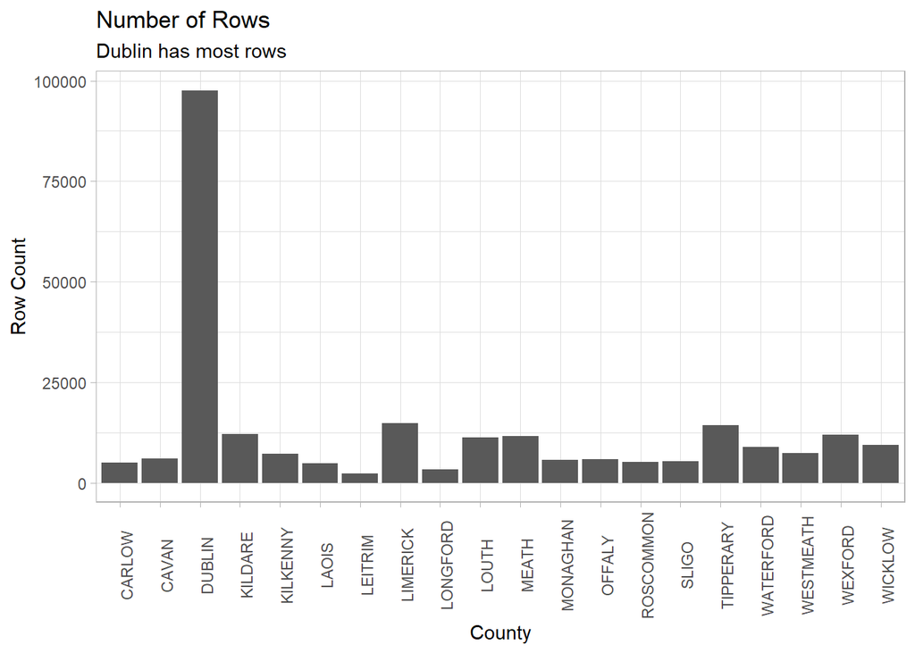

```r
theme_set(theme_light())

ireland_valoff_records %>%
  ggplot() +
  geom_bar(aes(County)) +
  theme(axis.text.x = element_text(angle = 90)) +
  labs(x = 'County',
       y = 'Row Count',
       title = 'Number of Rows',
       subtitle = 'Dublin has most rows')
```

The above plot is not necessarily useful, as it shows the number of rows in the data, not the number of properties. We need to isolate the property records from the floor records. We will need to normalise on the Property Number field..

```r
property_records <- ireland_valoff_records  %>%
  group_by(`Property Number`, County, `Local Authority`, Valuation, Category, Uses, `Address 1`, `Address 2`, `Address 3`, `Address 4`, `Address 5`, `X ITM`, `Y ITM`) %>%
  summarise(total_area = sum(Area),
         num_levels = n_distinct(Level),
         min_level = min(Level),
         max_level = max(Level))
```

The “Hospitality” category has had some information redacted for commercial purposes, so for the purposes of this analysis will be discarded.

```r
property_records %<>% filter(Category != "HOSPITALITY") %>% ungroup()
ireland_valoff_records %<>% filter(Category != "HOSPITALITY")
```

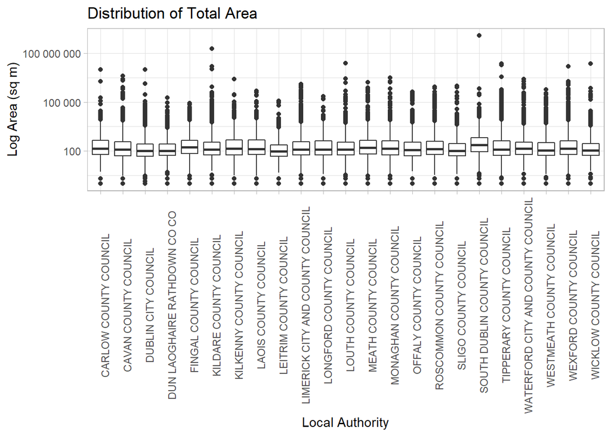

```r
# let's look at the distribution of total areas first
property_records %>%
  mutate(total_area = abs(total_area)) %>%
  ggplot(aes(`Local Authority`, total_area)) +
  geom_boxplot() +
  scale_y_log10(labels = number_format()) +
  theme(axis.text.x = element_text(angle = 90)) +
  labs(x = 'Local Authority',
       y = 'Log Area (sq m)',
       title = 'Distribution of Total Area')
```

```r
property_records %>%
  filter(total_area > 1000000) %>%
  arrange(desc(total_area))
```

```
## # A tibble: 40 x 17
##    `Property Numbe~ County `Local Authorit~ Valuation Category Uses  `Address 1`
##    <chr>            <chr>  <chr>                <dbl> <chr>    <chr> <chr>
##  1 2181602          DUBLIN SOUTH DUBLIN CO~   8566000 UTILITY  NETW~ Storm Wate~
##  2 1739214          KILDA~ KILDARE COUNTY ~   1493000 UTILITY  NETW~ Sundry Tow~
##  3 2209450          LOUTH  LOUTH COUNTY CO~    506000 FUEL/DE~ MOTO~ LOCAL NO/M~
##  4 2209451          LOUTH  LOUTH COUNTY CO~    488000 FUEL/DE~ MOTO~ LOCAL NO/M~
##  5 5007301          WICKL~ WICKLOW COUNTY ~    540000 FUEL/DE~ MOTO~ LOCAL NO/M~
##  6 5005713          TIPPE~ TIPPERARY COUNT~    523000 FUEL/DE~ MOTO~ LOCAL NO/M~
##  7 2211239          TIPPE~ TIPPERARY COUNT~    350000 FUEL/DE~ MOTO~ Wallers Lo~
##  8 5005902          TIPPE~ TIPPERARY COUNT~    421000 FUEL/DE~ MOTO~ LOCAL NO/M~
##  9 2008904          WEXFO~ WEXFORD COUNTY ~    224000 FUEL/DE~ OIL ~ 11C MARSHM~
## 10 2211665          KILDA~ KILDARE COUNTY ~    348000 FUEL/DE~ MOTO~ Local No/M~
## # ... with 30 more rows, and 10 more variables: `Address 2` <chr>, `Address
## #   3` <chr>, `Address 4` <chr>, `Address 5` <chr>, `X ITM` <dbl>, `Y
## #   ITM` <dbl>, total_area <dbl>, num_levels <int>, min_level <chr>,
## #   max_level <chr>
```

```r
property_records %>%
  ungroup() %>%
  filter(total_area > 1000000) %>%
  count(Category)
```

```
## # A tibble: 6 x 2
##   Category            n
##   <chr>           <int>
## 1 FUEL/DEPOT         21
## 2 INDUSTRIAL USES    11
## 3 MINERALS            1
## 4 MISCELLANEOUS       2
## 5 RETAIL (SHOPS)      1
## 6 UTILITY             4
```

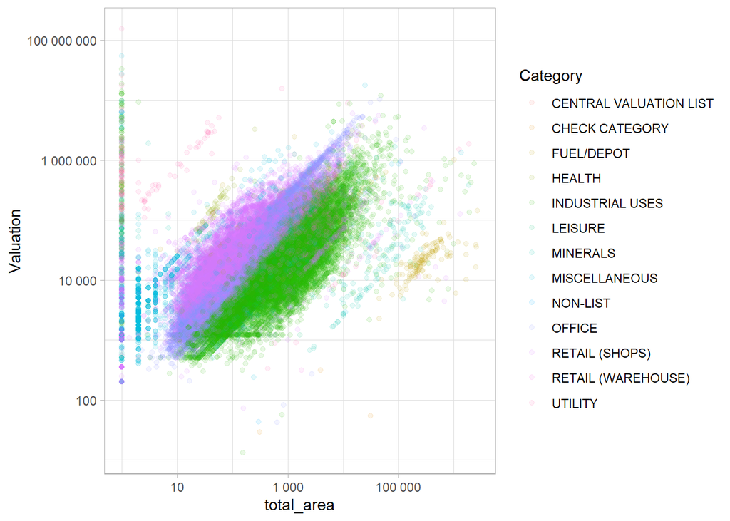

```r
property_records_lt_30m_sqm <- property_records  %>%
  filter(!(is.na(total_area) | total_area > 3000000))

property_records_lt_30m_sqm %>%
  mutate(total_area = abs(total_area),
         Valuation = abs(Valuation)) %>%
  filter(total_area > 0 & Valuation > 0) %>%
  ggplot() +
  geom_point(aes(x = total_area, y = Valuation, color = Category), alpha = 0.1) +
  scale_y_log10(labels = number_format()) +
  scale_x_log10(labels = number_format())
```

## Export for Tableau

First create a neat “floors” dataset - remove the common variables

Second, make a subset of the uid, x and y coords to parse into a geojson file in WGS84. The dataset has coords in ITM95 which has a CRS of 2157. The *sf* library is loaded and the *st_as_sf* function is used to create the simeple features representation of the data. We then reproject to WGS84 (crs 4326) and write it out as a geojson file.

Third, make a neat property_records dataset.

```r
# floors

ireland_valoff_records %>%
  select(-c(2:15)) -> valoff_floors

valoff_floors %>% write_csv("op/valoff_floors.csv")

# spatial
library(sf)

property_records %>%
  select(`Property Number`, `X ITM`, `Y ITM`) %>%
  filter(!(is.na(`X ITM`))) %>%
  st_as_sf(coords = c("X ITM", "Y ITM"), crs = 2157) %>%
  st_transform(4326) %>%
  st_write("op/property_locations.geojson")

property_records %>%
  select(-c(`X ITM`, `Y ITM`)) %>%
  write_csv("op/properties.csv")
```